# Statistical_Rethinking_Lecture_Homework_2019

3. This problem is more open-ended than the others. Feel free to collaborate on the solution. Suppose you want to estimate the Earth’s proportion of water very precisely. Specifically, you want the 99% percentile interval of the posterior distribution of p to be only 0.05 wide. This means the distance between the upper and lower bound of the interval should be 0.05. How many times will you have to toss the globe to do this? I won’t require a precise answer. I’m honestly more interested in your approach

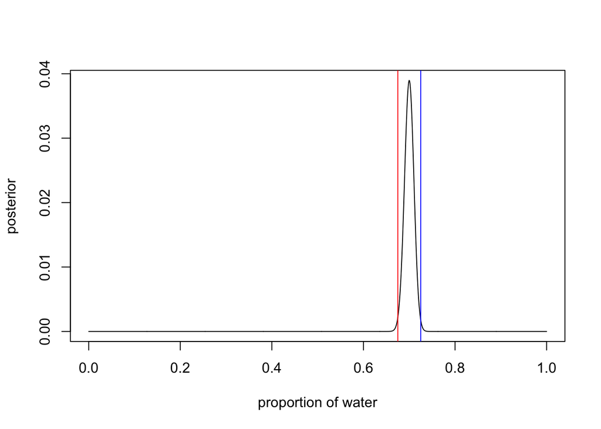

```r
# Create data frame
p_grid <- seq(from = 0, to = 1, length.out = 1000)

# Create prior
prior <- rep(0.7, 1000)

# Calculate likelihood
likelihood <- dbinom(1400, size = 2000, prob = p_grid)

# Calculate unstandardized posterior
unstd.posterior <- prior * likelihood

# Standardise the posterior
posterior <- unstd.posterior/ sum(unstd.posterior)

# Plot the posterior
plot(posterior~p_grid, type = "l", xlab = "proportion of water")
abline(v = 0.725, col = "blue")
abline(v = 0.675, col = "red")
```

```r
# The answer is 2,000 tosses if we know true value of p = 0.7.
```

$~$

*Given answer*

```r
# One way to approach this problem is to try a range of sample sizes and to
# plot the interval width of each. Here’s some code to compute the posterior
# and get the interval width:

set.seed(100)
N <- 20
p_true <- 0.7
W <- rbinom( 1 , size=N , prob=p_true )
p_grid <- seq( from=0 , to=1 , length.out=1000 )
prior <- rep( 1 , 1000 )
prob_data <- dbinom( W , size=N , prob=p_grid )
posterior <- prob_data * prior
posterior <- posterior / sum(posterior)
samples <- sample( p_grid , prob=posterior , size=1e4 , replace=TRUE )
PI99 <- PI( samples , 0.99 )
as.numeric( PI99[2] - PI99[1] )
```

```
## [1] 0.4544595
```

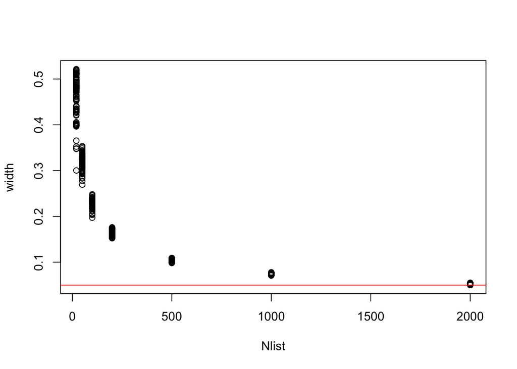

```r
# Now since we want to do this for different values of N,
# it’s nice to make this into a function:
f <- function( N ) {
p_true <- 0.7
W <- rbinom( 1 , size=N , prob=p_true )
p_grid <- seq( from=0 , to=1 , length.out=1000 )
prior <- rep( 1 , 1000 )
prob_data <- dbinom( W , size=N , prob=p_grid )
posterior <- prob_data * prior
posterior <- posterior / sum(posterior)
samples <- sample( p_grid , prob=posterior , size=1e4 , replace=TRUE )
PI99 <- PI( samples , 0.99 )
as.numeric( PI99[2] - PI99[1] )
}

# Now if you enter f(20), you get an interval width for 20 globe tosses.
# Now notice that the interval width varies across simulations. Try f(20) a
# few times to see what I mean. But as you increase N, this variation shrinks
# rapidly. This is because as the sample size increases, the differences between
# samples shrink. So if you ignore the sample to sample variation in interval
# width, that’s okay in this example. But in the code below, I’ll account for it.

#Now we need to run simulations across a bunch of different sample size to
# find where the interval shrinks to 0.05 in width. I’ll use sapply to run 100
# simulations at each of 7 sample sizes:
Nlist <- c( 20 , 50 , 100 , 200 , 500 , 1000 , 2000 )
Nlist <- rep( Nlist , each=100 )
width <- sapply( Nlist , f )
plot( Nlist , width )
abline( h=0.05 , col="red" )
```

```r
# The horizontal is sample size. The points are individual interval widths,
# one for each simulation. The red line is drawn at a width of 0.05.
# Looks like we need more than 2000 tosses of the globe to get the interval to be that precise.

# The above is a general feature of learning from data: The greatest returns
# on learning come early on. Each additional observation contributes less and
# less. So it takes very much effort to progressively reduce our uncertainty. So
# if your application requires a very precise estimate, be prepared to collect a
# lot of data. Or to change your approach
```